← Back to R & Statistics

# Seatbelt & Accident Survivors - My Simple Logistic Regression

### Background

Safety is a fundamental concern for all drivers and passengers, and seatbelts are often considered the primary safety measure in vehicles. Seatbelts are widely claimed to significantly reduce injuries and fatalities when accidents occur. While this protective role is generally accepted, it is crucial to understand precisely how effective seatbelts are in protecting occupants during a crash.

To investigate the true extent of seatbelt effectiveness, this study utilizes logistic regression—a robust statistical method suitable for analyzing binary outcomes such as survival or fatality. Through logistic regression, we will examine real-world accident data to determine the likelihood of survival with and without seatbelt usage.

The dataset was taken from Kaggle( Dataset Source)

### Dataset

This dataset was taken from kaggle. Here is the description provided by kaggle about the dataset:“This dataset contains detailed records of simulated road accident data, focusing on factors influencing survival outcomes. The dataset includes demographic, behavioral, and situational attributes, providing valuable insights into how various factors impact the survival probability during road accidents.”

```r
datatable(accident |> select(Seatbelt_Used, Survived))
```

|  | Seatbelt_Used | Survived |
| --- | --- | --- |
| 1 | 0 | 1 |
| 2 | 1 | 1 |
| 3 | 1 | 0 |
| 4 | 1 | 0 |
| 5 | 1 | 0 |
| 6 | 1 | 1 |
| 7 | 1 | 1 |
| 8 | 1 | 1 |
| 9 | 0 | 1 |
| 10 | 0 | 1 |

[output cut: 190 more lines]

### Hypothesis

Surviving after an accident based on wether the survivor wore a seatbelt or not can be modelized by the following simple logistic regression:

$$P(Y_i = 1|\, x_i) = \frac{e^{\beta_0 + \beta_1 x_i}}{1+e^{\beta_0 +
\beta_1 x_i}} = \pi_i$$

In this logistic regression model, for each accident , we define the following:

- $Y_i$ = 1 :Indicates the individual (driver or passenger) survived the accident.
- $Y_i$ = 0 :Indicates the individual (driver or passenger) did not survive the accident.
- $X_i$ : Represents whether the individual (driver or passenger) used a seatbelt during the accident (1 if used, 0 if not used).

This binary response variable along with the explanatory variable allows us to statistically evaluate the effectiveness of seatbelt use on survival probability.

$$H_0: \beta_1 = 0$$
$$H_a: \beta_1 \neq 0$$
with the level of significance $\alpha$ = 0.05

### Analysis

The estimates of the coefficients $\beta_0$ and $\beta_1$ for the above logistic regression model and data are shown below:

```r
accident_uftest <- accident |>
  select(Seatbelt_Used, Survived)
accident.glm <- glm((Survived == 1) ~ Seatbelt_Used, data = accident_uftest, family = binomial)

summary(accident.glm) |> pander(caption = "Logistic Regression Test Result")
```

|  | Estimate | Std. Error | z value | Pr(>\|z\|) |
| --- | --- | --- | --- | --- |
| **(Intercept)** | -0.1125 | 0.2123 | -0.5297 | 0.5963 |
| **Seatbelt_Used** | 0.2388 | 0.2851 | 0.8376 | 0.4023 |

(Dispersion parameter for binomial family taken to be 1 )

| Null deviance: | 277.2 on 199 degrees of freedom |
| --- | --- |
| Residual deviance: | 276.5 on 198 degrees of freedom |

The results of the hypothesis test indicate that the estimated coefficient $\beta_0$is -0.1125 and the estimated coefficient $\beta_1$ is 0.2388. The p-value associated with $\beta_1$ is 0.4023, which is greater than our significance level of 0.05. Therefore, we fail to reject the null hypothesis $H_0$. This suggests there is insufficient statistical evidence to conclude that wearing a seatbelt significantly affects the survival probability of passengers or drivers.

Before trsuting this result, let’s prove if the applying logistic regression is doable with this dataset.

### Diagnosing the model

Deciding which goodness of fit test to use to determine if our logistic regression is a good fit depends on how the elements of the chosen columns repeat themselves.

Below is how often each value of the column Seatbelt_Used repeat themselves:

```r
pander(table(accident_uftest$Seatbelt_Used), caption = "0 = No seatbelt, 1 = use seatbelt")
```

0 = No seatbelt, 1 = use seatbelt Since No repeat itself 89 times and yes repeats itself 111, we will use the Deviance Goodness-of-fit Test. Residual deviance = 276.5 and the degree of freedom is 198 and the level of significance is $\alpha$ = 0.05

| 0 | 1 |
| --- | --- |
| 89 | 111 |

```r
library(ResourceSelection)
pchisq(276.5, 198,lower.tail = FALSE)
```

```
## [1] 0.0001919447
```

Since $P-Value < \alpha$, we have sufficient evidence to reject the null hypothesis of the deviance Goodness -of-fit Test which is: The the data is a good fit for the logistic regression model.

### Data Visualization

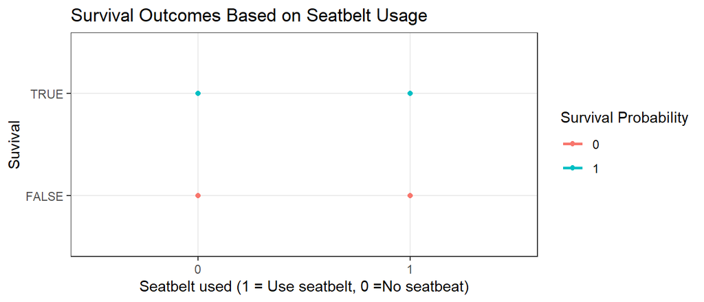

```r
b<- coef(accident.glm)

ggplot(data = accident, aes(x = as.factor(Seatbelt_Used), y = (Survived ==1), color = as.factor(Survived)))+
  geom_point()+
  geom_smooth(method = "glm", method.args = list(family = "binomial"), se = FALSE)+
  theme_bw()+
  labs(
    title = "Survival Outcomes Based on Seatbelt Usage",
    x = "Seatbelt used (1 = Use seatbelt, 0 =No seatbeat)",
    y = "Suvival",
    color = "Survival Probability"
  )
```

### Conclusion

Initially, the hypothesis test suggested no significant relationship between seatbelt usage and passenger survival probability (p-value = 0.4023), leading us to conclude that wearing a seatbelt had no statistically significant impact. However, upon conducting a Deviance Goodness-of-Fit Test (p-value < 0.05), we determined that our dataset is not adequately modeled by logistic regression. Consequently, we cannot confidently rely on our earlier conclusion regarding seatbelt usage, as logistic regression is not an appropriate model for this data. Further analysis using a different modeling approach is recommended.